# Имитационное моделирование

Лабораторная работа №8. Реализация основных моделей в дискретно-событийном подходе

Исаева Зарина Исмайилбековна

Российский университет дружбы народов имени Патриса Лумумбы

2026-09-08

# 1 Информация

## 1.1 Докладчик

- Исаева Зарина Исмайилбековна
- Студентка
- Российский университет дружбы народов имени Патриса Лумумбы
- Студенческий билет 1132232882

# 2 Цель и задачи

## 2.1 Цель работы

- Изучить распространение инфекции через индивидуальные события
- Реализовать модель SIR на Julia с ConcurrentSim
- Исследовать параметры и семь расширений из главы 8
- Сопоставить событийные траектории с ОДУ
- Получить выполненные IPYNB, JL и QMD через Literate

## 2.2 Задание

1. Подготовить Julia-проект и закрепить зависимости
2. Реализовать индивидуальные контакты и выздоровление
3. Выполнить базовый опыт и сохранить CSV
4. Исследовать параметры, длительность и производительность
5. Добавить рождения, смерти, вакцинацию и стадию E
6. Сопоставить модель с ОДУ и проверить инварианты
7. Выполнить литературные сценарии в Jupyter

## 2.3 Базовые условия

| Величина | Значение |
| --- | --- |
| S₀, I₀, R₀ | 990, 10, 0 |
| β, c, γ | 0.05, 10, 0.25 |
| Горизонт | 40 |
| Seed | 1234 |

# 3 Подготовка проекта

## 3.1 Окружение Julia

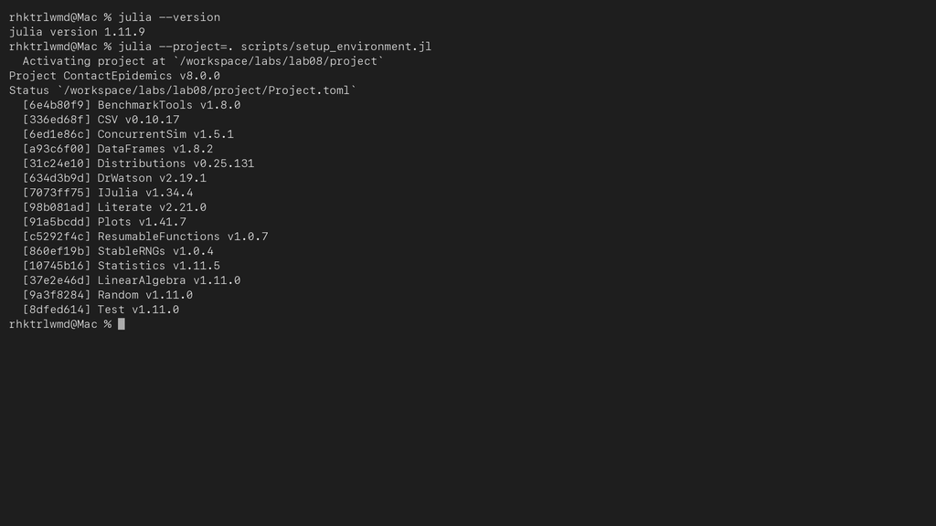

## 3.2 Зависимости проекта

- `ConcurrentSim`, `ResumableFunctions` — индивидуальные процессы
- `StableRNGs`, `Distributions` — случайные времена и повторяемые опыты
- `DataFrames`, `CSV`, `Plots` — таблицы и графики
- `Literate`, `IJulia` — литературный код и выполненные блокноты
- `BenchmarkTools` — измерение времени и выделений памяти

# 4 Структура решения

## 4.1 Контакты и выздоровление

- Восприимчивый агент ждёт Exp(1/c), выбирает другого живого агента и заражается с вероятностью β при контакте с I
- Инфекция длится Exp(1/γ)

## 4.2 Связь с ОДУ

$$dS/dt=-\beta cSI/(N-1)$$
$$dI/dt=\beta cSI/(N-1)-\gamma I,\quad dR/dt=\gamma I$$

Исключение самого агента даёт N−1 в знаменателе. Начальное эффективное число воспроизводства около 1.982.

## 4.3 Устройство реализации

- Ядро хранит состояния, очередь событий и список живых агентов
- Каждый переход обновляет единый журнал
- Отложенное событие проверяет, остаётся ли агент живым и находится ли в ожидаемом состоянии

## 4.4 Производные форматы

- Девять литературных исходников → чистые JL, выполненные IPYNB и QMD
- Полные QMD включены в тематические разделы отчёта

# 5 Базовый запуск

## 5.1 Базовый опыт

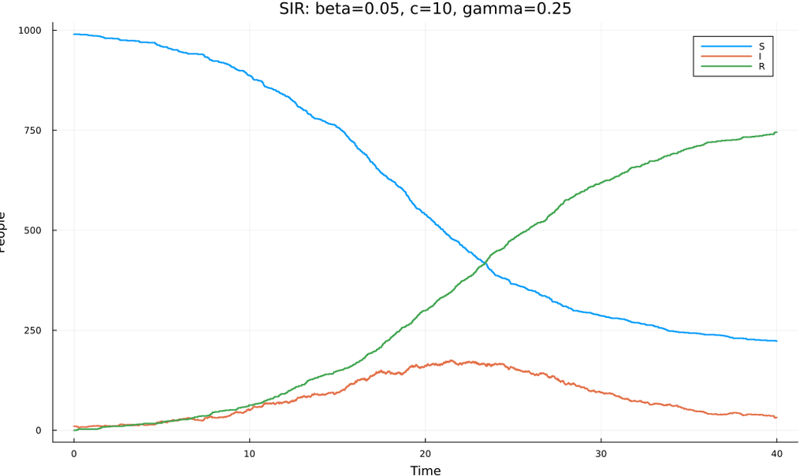

## 5.2 Выполненный базовый ноутбук

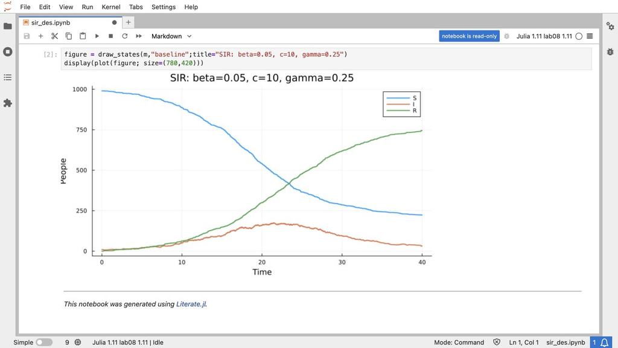

- Блокнот получен из `scripts/sir_des.jl`
- Ячейки выполнены; график построен по журналу событий

## 5.3 Численные результаты базового запуска

| Показатель | Значение |
| --- | --- |
| Максимум I | 175 |
| Время максимума | 21.4162 |
| S(40), I(40), R(40) | 223, 32, 745 |
| Накопленные инфекции | 777 |

## 5.4 Базовый опыт: интерпретация

- Базовый опыт использует исходные параметры без изменения
- R(40) описывает число выздоровевших к горизонту; при I(40)>0 это не окончательный размер эпидемии

# 6 Параметрическое исследование

## 6.1 Чувствительность к параметрам

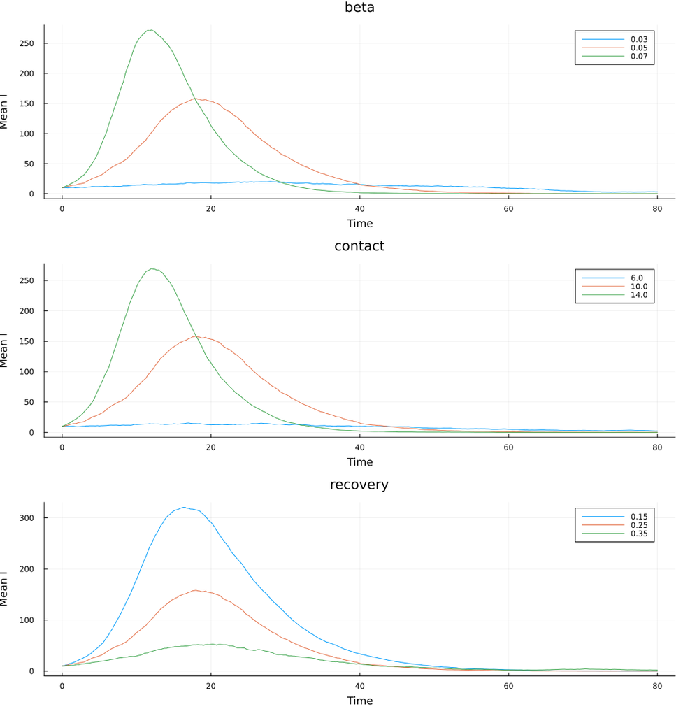

## 6.2 Чувствительность к параметрам: интерпретация

- Рост β и c усиливает передачу, рост γ сокращает инфекционный период
- Для сравнения используются средние метрики 20 повторов
- Горизонт расширен до 80 отдельно от базового опыта

## 6.3 Длительность инфекции

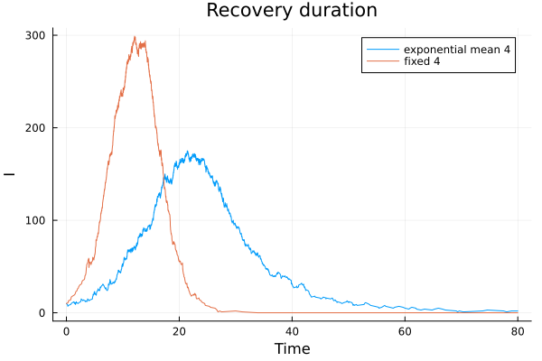

## 6.4 Длительность инфекции: численные результаты

| fixed | peak | time_peak |
| --- | --- | --- |
| false | 175 | 21.42 |
| true | 299 | 12.08 |

## 6.5 Длительность инфекции: интерпретация

- Фиксированный период устраняет длинный хвост времени болезни
- Одинаковое зерно не означает одинаковую последовательность контактов после расхождения очередей событий

## 6.6 Производительность

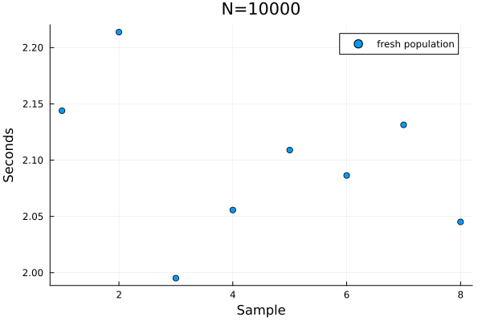

## 6.7 Производительность: численные результаты

| N | samples | median_seconds | allocated_bytes |
| --- | --- | --- | --- |
| 10000 | 8 | 2.098 | 1215293328 |

## 6.8 Производительность: интерпретация

- Время измеряется только для выполнения активированной модели. setup создаёт новую модель перед каждым образцом, evals=1 исключает измерение уже завершённого процесса
- Allocated bytes означает суммарные выделения, а не пиковую резидентную память
- Для ускорения стоит уменьшать выделения объектов событий и стоимость контактов

## 6.9 Анализ сохранённых CSV

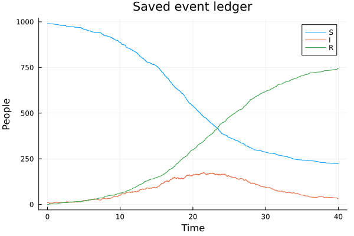

## 6.10 Анализ сохранённых CSV: интерпретация

- Сценарий читает ранее созданный файл и проверяет баланс
- В нём отсутствует вызов simulate, поэтому график является результатом анализа сохранённых данных

## 6.11 Рождения и смерти

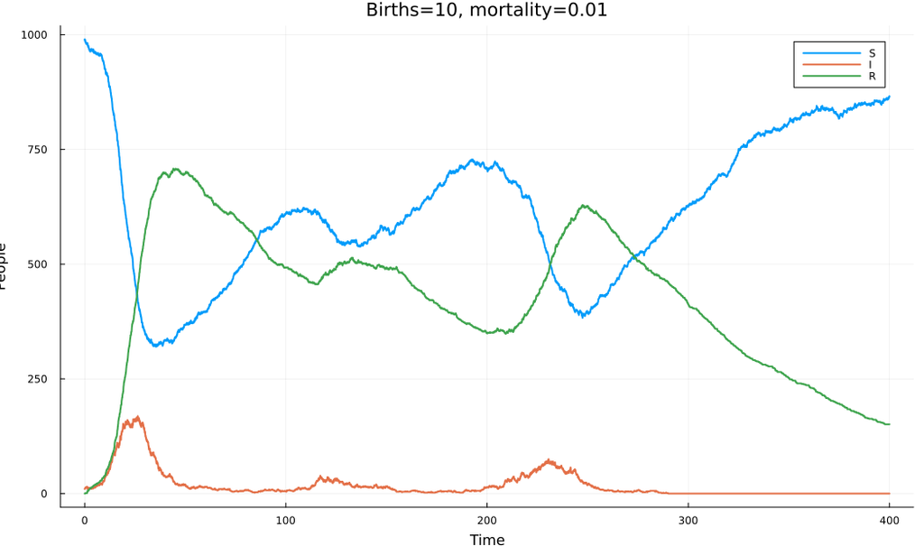

## 6.12 Рождения и смерти: численные результаты

| I_T | population | births | deaths |
| --- | --- | --- | --- |
| 0 | 1016 | 4242 | 4226 |

## 6.13 Рождения и смерти: интерпретация

- При Λ=10 и μ=0.01 средняя равновесная численность равна 1000
- Для приближения с частотной передачей эндемические значения около S*=520 и I*=18.46
- Положительное равновесие ОДУ не гарантирует сохранение инфекции в конечной популяции без заноса
- Один опыт T=400 не является статистическим доказательством стационарности

## 6.14 Вакцинация

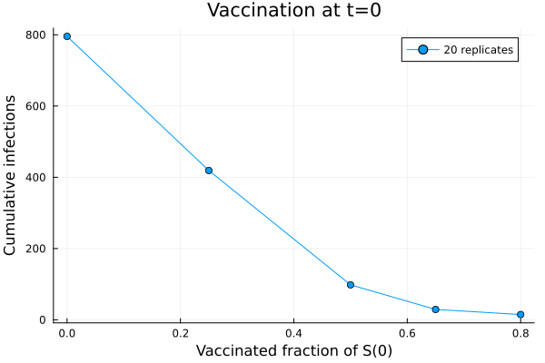

## 6.15 Вакцинация: численные результаты

| fraction | mean_peak | mean_cases |
| --- | --- | --- |
| 0 | 179.3 | 795.5 |
| 0.25 | 63.2 | 419.1 |
| 0.5 | 18.35 | 98.05 |
| 0.65 | 11.55 | 29 |
| 0.8 | 10.35 | 14.75 |

## 6.16 Вакцинация: интерпретация

- Порог раннего роста около 49.55% относится к доле исходных восприимчивых
- Опыты с долями 0, 0.25, 0.5, 0.65 и 0.8 показывают изменение среднего накопленного числа инфекций
- Вакцинированные не включаются в cases

## 6.17 Латентная стадия

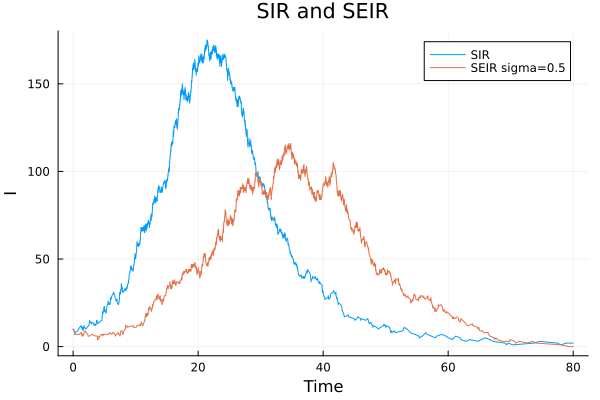

## 6.18 Латентная стадия: численные результаты

| sigma | peak | time_peak |
| --- | --- | --- |
| inf | 175 | 21.42 |
| 0.5 | 116 | 34.51 |

## 6.19 Латентная стадия: интерпретация

- Латентная стадия откладывает появление инфекционных агентов
- После смерти отложенное событие E→I отменяется проверкой состояния
- Помимо сравнения I сохранены все четыре ряда S/E/I/R

## 6.20 Сопоставление с ОДУ

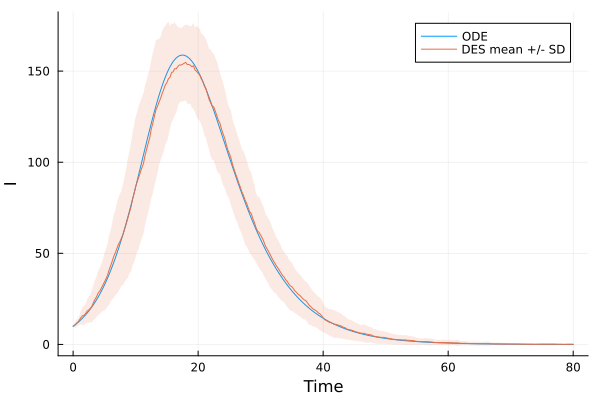

## 6.21 Сопоставление с ОДУ: численные результаты

| ode_peak | peak_mean_path | mean_individual_peak |
| --- | --- | --- |
| 158.8 | 154.8 | 175.4 |

## 6.22 Сопоставление с ОДУ: интерпретация

- RK4 проверяется уменьшением шага с 0.01 до 0.005
- Полоса вокруг среднего DES показывает стандартное отклонение траекторий, а не доверительный интервал среднего
- Максимум средней траектории и среднее индивидуальных максимумов вычисляются отдельно

# 7 Результаты

## 7.1 Баланс и конкурирующие события

- S+E+I+R=N₀+B−D проверяется по всему журналу
- Отдельные тесты покрывают смерть, вакцинацию, SEIR и малую популяцию

## 7.2 Результат тестирования

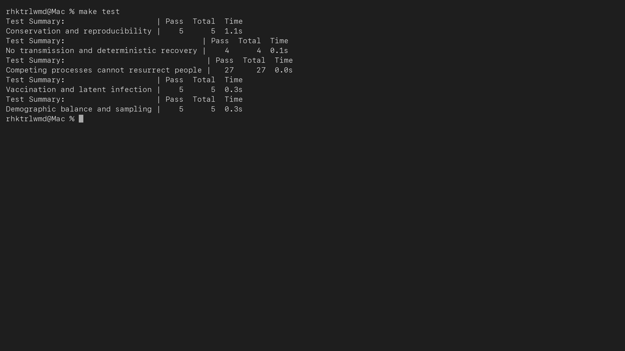

# 8 Выводы

## 8.1 Основные результаты

- Индивидуальные события воспроизводят случайные траектории SIR
- Параметрические опыты разделяют влияние β, c и γ
- Расширения модели сохраняют баланс и корректность отложенных событий

## 8.2 Ограничения интерпретации

- R(T) при I(T)>0 не является окончательным размером эпидемии
- Вакцинированные учитываются отдельно от инфицированных
- Пик среднего ансамбля отличается от среднего индивидуальных пиков

## 8.3 Источники

Королькова А. В., Кулябов Д. С. Имитационное моделирование. Практикум. Глава 8, страницы 221–234, 2026.

ConcurrentSim.jl и Literate.jl: официальная документация. Keeling M. J., Rohani P. Modeling Infectious Diseases in Humans and Animals, 2008.